# Homework Assignment 3

Murilo Pereira

2/13/2021

```r
knitr::opts_chunk$set(echo = TRUE)
```

# Nonlinear Gaussian regression

$$\begin{align}
l(y;x,\sigma^{2}, \gamma,\beta) &= f(y;x,\sigma^{2}, \gamma,\beta) \\
& \propto (\sigma^{-2})^{-n / 2} \exp \left\{-\frac{\sigma^{-2}}{2}(y-G \beta)^{\prime}(y-G \beta)\right\} \\
& \propto (\sigma^{-2})^{-n / 2} \exp \left\{-\frac{\sigma^{-2}}{2}((\beta-\hat{\beta})^{\prime} G^{\prime} G(\beta-\hat{\beta}) + S_e)\right\}
\end{align}$$
where $\hat{\beta} = (G'G)^{-1}G'y$ and $S_e = (y-G \hat{\beta})^{\prime}(y-G \hat{\beta}) = \sum_{i=1}^{n} e_{i}^{2}$.

Combining now with the prior for $\beta | \sigma^2$ we have
$$\begin{align}
p\left(\beta \mid x, y, \sigma^{2}, \gamma\right) &\propto (\sigma^{-2})^{-d / 2} \exp \left\{-\frac{\sigma^{-2}}{2}((\beta-\hat{\beta})^{\prime} G^{\prime} G(\beta-\hat{\beta}) + S_e)\right\} \\
&\times (\sigma^{-2})^{-n / 2} \exp \left\{-\frac{\sigma^{-2}}{2}\left[\left(\beta-b_{0}\right)^{\prime} B_{0}^{-1}\left(\beta-b_{0}\right)\right]\right\} \\
& \propto (\sigma^{-2})^{-(d +n )/ 2} \exp \left\{-\frac{\sigma^{-2}}{2}\left((\beta-\hat{\beta})^{\prime} G^{\prime} G(\beta-\hat{\beta}) + S_e + \left(\beta-b_{0}\right)^{\prime} B_{0}^{-1}\left(\beta-b_{0}\right)\right) \right\}
\end{align}$$

2. Now I’ll show that $p\left(\sigma^{2} \mid x, y, \beta, \gamma\right)$ follows an Inverse-Gamma distribution.
   $$p\left(\sigma^{2} \mid x, y, \beta, \gamma\right) \propto f(y;x,\sigma^{2}, \gamma,\beta)p(\sigma^2)$$

hence

$$\begin{align}
p\left(\sigma^{2} \mid x, y, \beta, \gamma\right) &\propto (\sigma^{-2})^{n/2}\exp \left\{-\frac{1}{2 \sigma^{2}}\left[\beta_{1}^{2} \sum_{i=1}^{n} g^{2}\left(x_{i}, \gamma\right)-2\sum_{i=1}^{n}\left(y_{i}-\beta_{0}\right) g\left(x_{i}, \gamma\right)\right]\right\} \\
& \times (\sigma^2)^{-\alpha_1-1}exp\left\{\dfrac{-\alpha_2}{\sigma^2} \right\} \\
p\left(\sigma^{2} \mid x, y, \beta, \gamma\right) &\propto (\sigma^2)^{-(\alpha_1+n/2)-1}exp\left\{-\dfrac{\alpha_2+\beta_{1}^{2}/2 \sum_{i=1}^{n} g^{2}(x_{i}, \gamma)-\sum_{i=1}^{n}(y_{i}-\beta_{0})g(x_{i}, \gamma)}{\sigma^2}\right\} \\
p\left(\sigma^{2} \mid x, y, \beta, \gamma\right) &\propto (\sigma^2)^{-\alpha_{post}-1}exp\left\{-\dfrac{\beta_{post}}{\sigma^2} \right\}
\end{align}$$

where

$$\begin{align}
\alpha_{post} &= \alpha_1+n/2 \\
\beta_{post} &=\alpha_2+\beta_{1}^{2}/2 \sum_{i=1}^{n} g^{2}(x_{i}, \gamma)-\sum_{i=1}^{n}(y_{i}-\beta_{0})g(x_{i}, \gamma)
\end{align}$$

3. I’ll now calculate $p\left(\sigma^{2} \mid x, y, \gamma\right)$, since the prior of $\beta$ is conditional on $\sigma^2$, $p\left(\sigma^{2} \mid x, y, \gamma\right)$ is also an Inverse-Gamma. Using matrix notation we have that
   $$p\left(\sigma^{2},\beta \mid x, y, \gamma\right) \propto f(y;x,\sigma^{2}, \gamma,\beta)p(\beta |\sigma^2)p(\sigma^2)$$
   hence, using the derivation in item (a) and the prior for $\sigma^2$

$$\begin{align}
p\left(\sigma^{2},\beta \mid x, y, \gamma\right) &\propto (\sigma^{-2})^{-d / 2} \exp \left\{-\frac{\sigma^{-2}}{2}((\beta-\hat{\beta})^{\prime} G^{\prime} G(\beta-\hat{\beta}) + S_e)\right\} \\
&\times (\sigma^{-2})^{-n / 2} \exp \left\{-\frac{\sigma^{-2}}{2}\left[\left(\beta-b_{0}\right)^{\prime} B_{0}^{-1}\left(\beta-b_{0}\right)\right]\right\}(\sigma^{-2})^{\left(v_{0} / 2\right)-1} \exp \left\{-\frac{\sigma^{-2}}{2} v_{0} \sigma^{-2}_{0}\right\} \\
& \propto (\sigma^{-2})^{-(d +n +v_0)/ 2-1} \exp \left\{-\frac{\sigma^{-2}}{2}\left((\beta-\hat{\beta})^{\prime} G^{\prime} G(\beta-\hat{\beta}) + S_e + \left(\beta-b_{0}\right)^{\prime} B_{0}^{-1}\left(\beta-b_{0}\right)\right) + v_0\sigma^{-2}_{0} \right\}
\end{align}$$
and the expression above is equivalente to
$$p\left(\sigma^{2},\beta \mid x, y, \gamma\right) \propto (\sigma^{-2})^{\frac{d}{2}} \exp \left\{-\frac{\sigma^{-2}}{2}\left(\beta-b_{1}\right)^{\prime} B_{1}^{-1}\left(\beta-b_{1}\right)\right\} (\sigma^{-2})^{\frac{n_{1}}{2}-1} \exp \left\{-\frac{\sigma^{-2}}{2} n_{1} \sigma^{2}_{1}\right\}$$
where $n_1 = v_0 + n$, $n_1\sigma_1^{2} = v_{0} \sigma^{2}_{0}+\left(y-G b_{1}\right)^{\prime} y+\left(b_{0}-b_{1}\right)^{\prime} B_{0}^{-1} b_{0}$, $b_1 = B_{1}\left(B_{0}^{-1} b_{0}+G^{\prime} y\right)$ and $B_{1}^{-1}=B_{0}^{-1}+G^{\prime} G$. Computing the posterior in terms of $\sigma^2$ we have the Inverse-Gamma distribution with $\alpha_1 = n_1/2$ and $\alpha_2 = \dfrac{n_1\sigma^2_1}{2}$.

4. MCMC algorithm that cycles through the full conditionals:

Gibbs sample of $\sigma^2$ from $p\left(\sigma^{2} \mid x, y, \beta, \gamma\right)$. Recall that $p\left(\sigma^{2} \mid x, y, \beta, \gamma\right)$ is an Inverse-Gamma distribution as derived in item (b), hence

$$\begin{align}
p\left(\sigma^{2} \mid x, y, \beta, \gamma\right) & \propto (\sigma^2)^{-\alpha_{post}-1}exp\left\{-\dfrac{\beta_{post}}{\sigma^2}\right\}
\end{align}$$

where

$$\begin{align}
\alpha_{post} &= \alpha_1+n/2 \\
\beta_{post} &=\alpha_2+\beta_{1}^{2}/2 \sum_{i=1}^{n} g^{2}(x_{i}, \gamma)-\sum_{i=1}^{n}(y_{i}-\beta_{0}g(x_{i}, \gamma))
\end{align}$$

```r
require("mvtnorm")
```

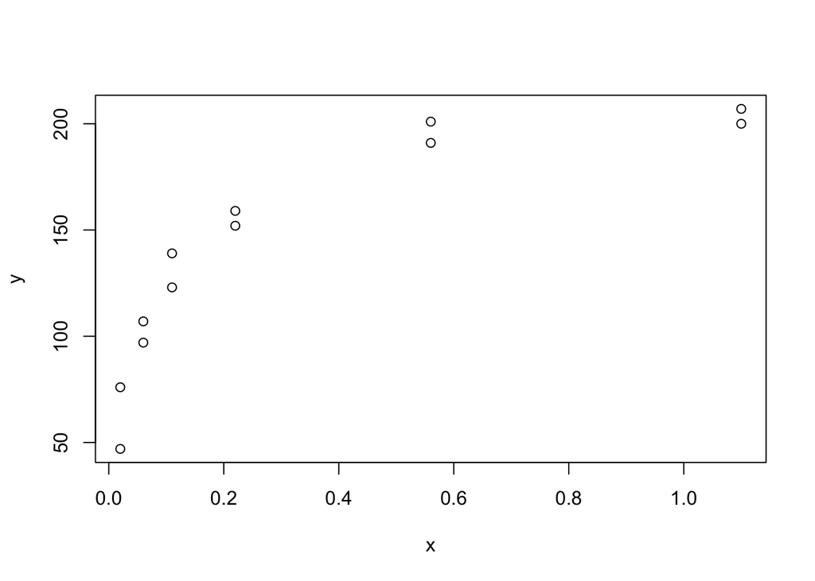

```r
library("mvtnorm")

x = c(0.02,0.02,0.06,0.06,0.11,0.11,0.22,0.22,0.56,0.56,1.10,1.10)
y = c(76,47,97,107,123,139,159,152,191,201,207,200)
plot(x,y)
```

```r
# Initial data
n = length(y)
d = length(x)
sig2.0 = 10
nu.0 = 5
nu.1 = nu.0+n
tau20 = 1
beta0.0 = 50
beta1.0 = 170
beta.0 = c(beta0.0,beta1.0)
beta.d = beta.0
B0 = diag(3,2)
iB0 = solve(B0)
b0 = rep(0,2)
iB0b0 = iB0%*%b0
gamma.d = 0
gamma.0 = 0

#Defining functions
mu      = function(gamma,x){beta.d[1]+beta.d[2]*x/(gamma+x)}
loglike = function(gamma){sum(dnorm(y,mu(gamma,x),sqrt(sig2.d),log=TRUE))}

set.seed(12345)
burnin = 10000
M      = 10000
niter  = burnin+M
draws  = matrix(0,niter,4)

# Cycling through the full conditionals
runtime = system.time({
for (iter in 1:niter){

g = x/(x+gamma.d)
G = cbind(1,g)
#g2 = sum((x/(gamma.d+x))^2)
#f = sum((y-beta.d[1])*x/(gamma.d+x))
#sig2.d = 1/rgamma(1,nu.0+n/2,nu.0*sig2.0/2+beta.d[2]^2/2*g2-f)
sig2.d = 1/rgamma(1,nu.0+n/2,nu.0*sig2.0/2+t(y-G%*%beta.d)%*%(y-G%*%beta.d)/2)

B1 = solve(iB0+t(G)%*%G)
b1 = B1%*%(iB0b0+t(G)%*%y)
beta.d = as.vector(rmvnorm(1,b1,sig2.d*B1))

# Metropolis-Hastings
gam = rnorm(1,gamma.d,0.005)
num = dnorm(gam,gamma.0,tau20,log=TRUE)+loglike(gam)
den = dnorm(gamma.d,gamma.0,tau20,log=TRUE)+loglike(gamma.d)

accept = exp(num-den)
  if (runif(1) < accept){
    gamma.d = gam }

draws[iter,] = c(beta.d,sig2.d,gamma.d)
}})
draws = draws[(burnin+1):niter,]
means = colMeans(draws); mean.beta0.d = means[1];mean.beta1.d = means[2];mean.sig2.d = means[3];mean.gamma.d = means[4]
runtime
```

```
##    user  system elapsed
##   8.397   0.109   9.783
```

5. Now I’ll repeat that steps made in item (d) but sampling $\sigma^2$ from $p\left(\sigma^{2} \mid x, y, \gamma\right)$.

```r
gamma.d = gamma.0
sig2.d  = sig2.0
gamma.d = gamma.0

set.seed(12345)
burnin = 10000
M      = 10000
niter  = burnin+M
drawss  = matrix(0,niter,4)

# Cycling through the full conditionals
runtime = system.time({
for (iter in 1:niter){

g = x/(x+gamma.d)
G = cbind(1,g)
B1 = solve(iB0+t(G)%*%G)
b1 = B1%*%(iB0b0+t(G)%*%y)
n1sig1 = nu.0*sig2.d + t(y-G%*%b1)%*%y + t(b0-b1)%*%iB0b0
sig2.d = 1/rgamma(1,nu.1/2,n1sig1/2)

beta.d = as.vector(rmvnorm(1,b1,sig2.d*B1))

# Metropolis-Hastings

gam = rnorm(1,gamma.d,0.005)
num = dnorm(gam,gamma.0,tau20,log=TRUE)+loglike(gam)
den = dnorm(gamma.d,gamma.0,tau20,log=TRUE)+loglike(gamma.d)

accept = exp(num-den)
  if (runif(1) < accept){
    gamma.d = gam }

drawss[iter,] = c(beta.d,sig2.d,gamma.d)

}})

drawss = drawss[(burnin+1):niter,]
runtime
```

```
##    user  system elapsed
##   8.131   0.055   8.622
```

6. Trace plots and autocorrelation functions

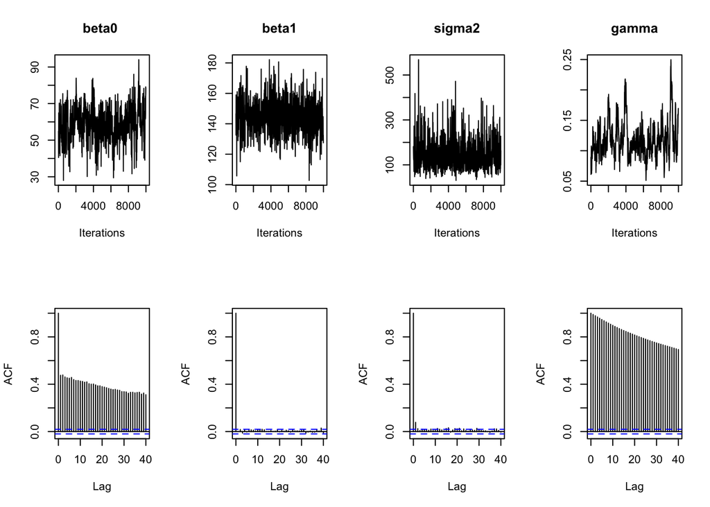

```r
par=c("beta0 ","beta1","sigma2","gamma")
par(mfrow=c(2,4))
ind = seq(1,M,by=10)

# Algorithm 1
for (i in 1:4)
  plot(ind,draws[ind,i],xlab="Iterations",ylab="",main=par[i],type="l")

for (i in 1:4)
  acf(draws[,i],main="")
```

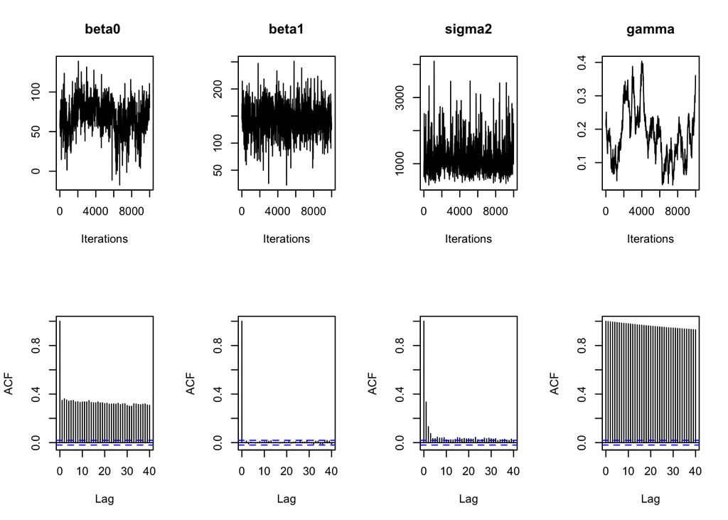

```r
# Algorithm 2
for (i in 1:4)
  plot(ind,drawss[ind,i],xlab="Iterations",ylab="",main=par[i],type="l")

for (i in 1:4)
  acf(drawss[,i],main="")
```

Calculating marginal posterior densities

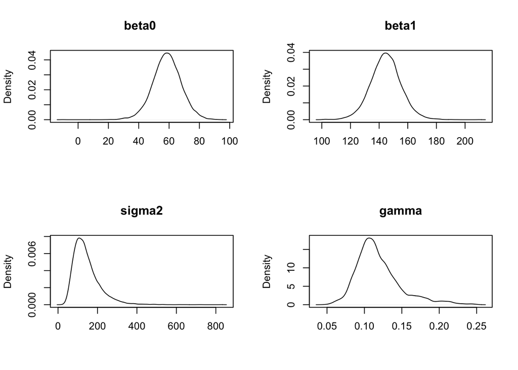

```r
par(mfrow=c(2,2))
for (i in 1:4){
  plot(density(draws[,i]),xlab="",main=par[i])
}
```

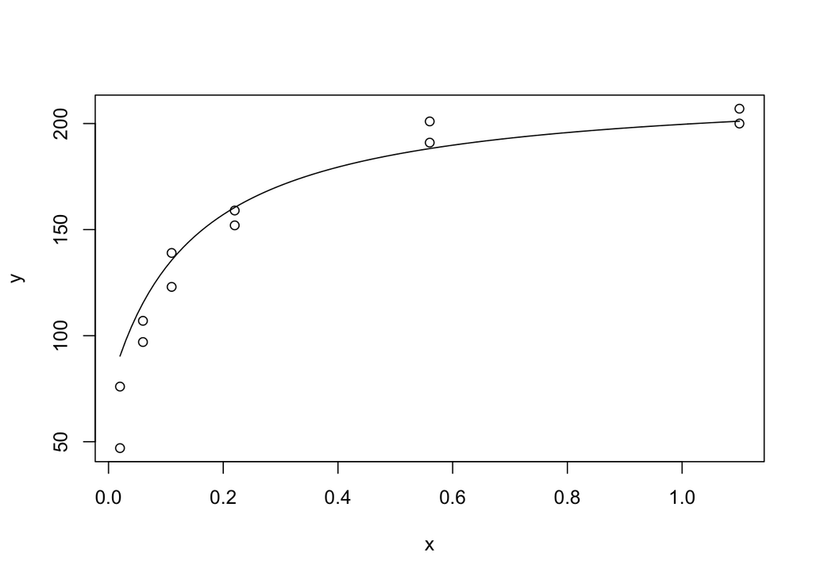

```r
beta0 = draws[,1]; beta1=draws[,2]; sigma2=draws[,3]; gamma1=draws[,4]
xx = seq(0.02,1.1,length=109)
M = 1000
for (i in 1:M){
y.d = beta0[i]+beta1[i]*xx/(gamma1[i]+xx)
}
plot(x,y)
lines(xx,y.d)
```

```r
#N = length(xx)
#M = 1000
#prob = function(xx,beta0,beta1,sigma2,gamma1){dnorm(xx,beta0+beta1*(1))}
#prob.bayes = matrix(0,M,N)
#for (i in 1:M){
#  prob.bayes[i,] = pnorm(beta0[i]+beta1[i]*xx/(xx+gamma1[i]), #mean=mean.beta0.d+mean.beta1.d*mean(xx)/(mean.gamma.d+mean(xx)),sd = sqrt(mean.sig2.d))
#}
```